# Tidyverse II

Sam Woodman

10/08/2020

# Packages

The following packages are necessary for this tutorial. Please note the versions of the installed packaged used to create this tutorial. If your packages differ from these then there may be differences.

```r
# install packages if they are not already present
# if they are the packages in the list are loaded
packages <- c("tidyverse","broom","tictoc", "gapminder", "patchwork", "modelr")

## Now load or install&load all
package.check <- lapply(
  packages,
  FUN = function(x) {
    if (!require(x, character.only = TRUE)) {
      install.packages(x, dependencies = TRUE)
      library(x, character.only = TRUE)
    }
  }
)
as.data.frame(installed.packages()[,c(1,3:4)]) %>%
  filter(Package %in% packages)
```

```
##     Package Version Priority
## 1     broom   0.5.5     <NA>
## 2 gapminder   0.3.0     <NA>
## 3    modelr   0.1.6     <NA>
## 4 patchwork   1.0.0     <NA>
## 5    tictoc     1.0     <NA>
## 6 tidyverse   1.3.0     <NA>
```

# Introduction

This tutorial is a continuation of the Tidyverse I tutorial given by James Ball on July 28-07-2020 and is a general introduction to functional programming through the tidyverse. We will be primarily exploring the *purrr* and *tidyr* packages, both of which are included when you load the *tidyverse*. Note that this is only an introduction. For more please check [Advanced R](https://adv-r.hadley.nz) and [R for Data Science](https://r4ds.had.co.nz). In many cases there are base R versions almost all tidyverse functions. The strength of the Tidyverse is that all the packages are designed to work together seamlessly.

# The *purrr* package

*purrr* is a toolkit for functional programming using functions, vectors, and lists. *purrr* can be used for splitting data into pieces and applying functions to those pieces. A cheatsheet of various *purrr* functions can be found [here](https://github.com/rstudio/cheatsheets/blob/master/purrr.pdf)

## Working with lists

The simplest introduction to *purrr* is to work with simple lists. Below are a series of examples of ways you can use *purrr* to interact with lists. I have only highlighted a few functions below. For more I recommend checking out the cheatsheet linked above.

```r
list.1 <- replicate(5, sample(1:100,size=10), simplify=FALSE) # create 5 lists of random numbers from 1 to 100

list.1
```

```
## [[1]]
##  [1]  68  78  92  60  93 100  89   1  64  62
##
## [[2]]
##  [1] 73 60 45 22 28 48 54 84 23 53
##
## [[3]]
##  [1] 60 67 47 81 89 66 23 37 74 12
##
## [[4]]
##  [1] 64  3 93 70 42 68  9  2 33 61
##
## [[5]]
##  [1] 26 84 23  8  7 80 82 55 34 70
```

```r
list.1 %>%
  pluck(2) # select an element by name or index. equivalent to list.1[[2]]
```

```
##  [1] 73 60 45 22 28 48 54 84 23 53
```

```r
list.1 %>%
  keep(~ sum(.x) > 450) # select elements taht pass a logical test
```

```
## [[1]]
##  [1]  68  78  92  60  93 100  89   1  64  62
##
## [[2]]
##  [1] 73 60 45 22 28 48 54 84 23 53
##
## [[3]]
##  [1] 60 67 47 81 89 66 23 37 74 12
##
## [[4]]
##  [1] 26 84 23  8  7 80 82 55 34 70
```

```r
list.1 %>%
  discard(~ sum(.x) > 450) # discard elements that pass a logical test
```

```
## [[1]]
##  [1] 64  3 93 70 42 68  9  2 33 61
```

```r
list.1 %>%
  flatten() # remove a level of indexing from a list
```

```
## [[1]]
## [1] 68
##
## [[2]]
## [1] 78
##
## [[3]]
## [1] 92
##
## [[4]]
## [1] 60
##
## [[5]]
## [1] 93
##
## [[6]]
## [1] 100
##
## [[7]]
## [1] 89
##
## [[8]]
## [1] 1
##
## [[9]]
## [1] 64
##
## [[10]]
## [1] 62
##
## [[11]]
## [1] 73
##
## [[12]]
## [1] 60
##
## [[13]]
## [1] 45
##
## [[14]]
```

[output cut: 94 more lines]

```
##
## [[46]]
## [1] 80
##
## [[47]]
## [1] 82
##
## [[48]]
## [1] 55
##
## [[49]]
## [1] 34
##
## [[50]]
## [1] 70
```

These functions can equally be applied to more complex lists. **list.2** below is a multi-level list but can still be manipulated using *purrr*

```r
list.2 <- rerun(5, x = runif(1), y = runif(5)) # create random list where each element has two internal elements, x and y

list.2
```

```
## [[1]]
## [[1]]$x
## [1] 0.9423045
##
## [[1]]$y
## [1] 0.2098744 0.8024951 0.9906728 0.6985551 0.8377407
##
##
## [[2]]
## [[2]]$x
## [1] 0.1735682
##
## [[2]]$y
## [1] 0.46262069 0.07670748 0.81842984 0.46522479 0.69715318
##
##
## [[3]]
## [[3]]$x
## [1] 0.4218208
##
## [[3]]$y
## [1] 0.5383501 0.6351974 0.9531651 0.6295043 0.6569481
##
##
## [[4]]
## [[4]]$x
## [1] 0.4093639
##
## [[4]]$y
## [1] 0.1488858 0.2169465 0.5578249 0.7955045 0.9904437
##
##
## [[5]]
## [[5]]$x
## [1] 0.6097025
##
## [[5]]$y
## [1] 0.5487168 0.6400184 0.2565291 0.2325861 0.6841984
```

```r
list.2 %>%
  pluck(2,2) # select an element within a list of lists. equivalent to list.2[[2]][[2]]
```

```
## [1] 0.46262069 0.07670748 0.81842984 0.46522479 0.69715318
```

```r
list.2 %>%
  transpose() # transpose the index order in multi-level lists
```

```
## $x
## $x[[1]]
## [1] 0.9423045
##
## $x[[2]]
## [1] 0.1735682
##
## $x[[3]]
## [1] 0.4218208
##
## $x[[4]]
## [1] 0.4093639
##
## $x[[5]]
## [1] 0.6097025
##
##
## $y
## $y[[1]]
## [1] 0.2098744 0.8024951 0.9906728 0.6985551 0.8377407
##
## $y[[2]]
## [1] 0.46262069 0.07670748 0.81842984 0.46522479 0.69715318
##
## $y[[3]]
## [1] 0.5383501 0.6351974 0.9531651 0.6295043 0.6569481
##
## $y[[4]]
## [1] 0.1488858 0.2169465 0.5578249 0.7955045 0.9904437
##
## $y[[5]]
## [1] 0.5487168 0.6400184 0.2565291 0.2325861 0.6841984
```

```r
list.2 %>%
  flatten() %>% # flatten to rermove multilevel
  keep(~ sum(.x) >2) # keep only elements that has a sum greater than 2
```

```
## $y
## [1] 0.2098744 0.8024951 0.9906728 0.6985551 0.8377407
##
## $y
## [1] 0.46262069 0.07670748 0.81842984 0.46522479 0.69715318
##
## $y
## [1] 0.5383501 0.6351974 0.9531651 0.6295043 0.6569481
##
## $y
## [1] 0.1488858 0.2169465 0.5578249 0.7955045 0.9904437
##
## $y
## [1] 0.5487168 0.6400184 0.2565291 0.2325861 0.6841984
```

## The *map* function

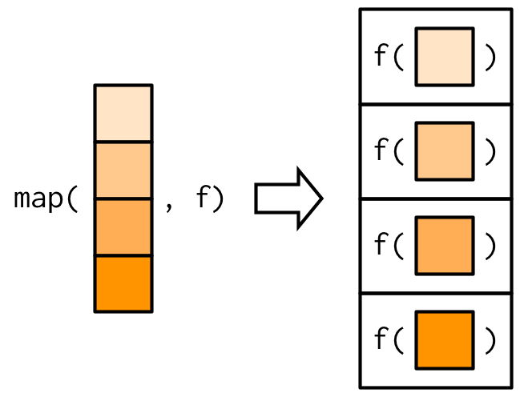

Illustration of how map works from Advanced R by Hadley Wickham

Run each of the examples below before attempting a different function (i.e. replace YOUR_FUNCTION_HERE and uncomment). Try any function that you woud typically use on a numerical vector.

```r
list.1 %>%
  map(sum) # apply sum across each list
```

```
## [[1]]
## [1] 707
##
## [[2]]
## [1] 490
##
## [[3]]
## [1] 556
##
## [[4]]
## [1] 445
##
## [[5]]
## [1] 469
```

```r
list.1 %>%
  map(mean) # calculate mean of each list
```

```
## [[1]]
## [1] 70.7
##
## [[2]]
## [1] 49
##
## [[3]]
## [1] 55.6
##
## [[4]]
## [1] 44.5
##
## [[5]]
## [1] 46.9
```

```r
list.1 %>%
  map(sd) # calculate standard deviation of each list
```

```
## [[1]]
## [1] 28.47631
##
## [[2]]
## [1] 20.61822
##
## [[3]]
## [1] 25.25514
##
## [[4]]
## [1] 31.85819
##
## [[5]]
## [1] 30.88131
```

```r
# l.1 %>%
#   map(YOUR_FUNCTION_HERE)
```

*map* is not limited to just existing functions. you can also write your own functions. Below are two examples of how to apply the same function to **list.1**. The first example writes the function separately before calling it in *map*. The second example use the **~** as a shortcut for writing a function within *map*. Both are valid and depend on your preference. However, I recommend only using the **~** when the function you are writing is simple.

```r
cv_fun <- function(x) {
  s <- sd(x)
  m <- mean(x)
  out <- s/m
  out
}

list.1 %>%
  map(cv_fun) # apply cv_fun to each list
```

```
## [[1]]
## [1] 0.4027766
##
## [[2]]
## [1] 0.4207801
##
## [[3]]
## [1] 0.4542292
##
## [[4]]
## [1] 0.7159144
##
## [[5]]
## [1] 0.6584502
```

```r
list.1 %>%
  map(~ sd(.)/mean(.)) # shorthand method of applying cv_fun to list
```

```
## [[1]]
## [1] 0.4027766
##
## [[2]]
## [1] 0.4207801
##
## [[3]]
## [1] 0.4542292
##
## [[4]]
## [1] 0.7159144
##
## [[5]]
## [1] 0.6584502
```

### Speed test

```r
list.3 <- replicate(10000, sample(1:100,size=20), simplify=FALSE) # create random list 10000 elements long

tic("lappy") # start measuring time to run, label "lapply" in output
l <- lapply(list.3, mean)
toc() # stop measuring time to run
```

```
## lappy: 0.054 sec elapsed
```

```r
tic("map")
m <-map(list.3,mean)
toc()
```

```
## map: 0.039 sec elapsed
```

You might not have seen much of a difference between the two. This is likely because the list was only 10000 elements long, each made up of a vector of length 20. If both these values were bigger the difference might become more obvious. You are welcome to try for yourself, I just made the list shorter to save time.

If you want speedy dataframe manipulation the *tidyverse* may not be best. The tidyverse is more about readability and consistent approach to data Try *[data.table](https://cran.r-project.org/web/packages/data.table/vignettes/datatable-intro.html)* for more efficient dataframe manipulation.

### Exercise

Using the *map* function determine the number of values above 50 in the ex_list below.

Hint: you might want to write your own function.

```r
ex_list <- list(runif(25, 0, 100),
                  runif(25, 0, 100),
                  runif(25, 0, 100),
                  runif(25, 0, 100))

filt_fun <- function(x) x[x >= 50]

ex_list %>%
  map(filt_fun) %>%
  map(length)
```

```
## [[1]]
## [1] 13
##
## [[2]]
## [1] 15
##
## [[3]]
## [1] 12
##
## [[4]]
## [1] 15
```

### Helper functions

As mentioned above *map* comes with several variations that help coerce your output to a desired output. If you know the data type of your output it can save you a step to use the variation of *map* that applies.

You’ll also notice that *map* is working perfectly across all the columns when used with the dataframe **mtcars**. This is because the dataframe only contains numeric columns. If we added a column of a different type it would result in an error.

```r
data(mtcars)

head(mtcars)
```

```
##                    mpg cyl disp  hp drat    wt  qsec vs am gear carb
## Mazda RX4         21.0   6  160 110 3.90 2.620 16.46  0  1    4    4
## Mazda RX4 Wag     21.0   6  160 110 3.90 2.875 17.02  0  1    4    4
## Datsun 710        22.8   4  108  93 3.85 2.320 18.61  1  1    4    1
## Hornet 4 Drive    21.4   6  258 110 3.08 3.215 19.44  1  0    3    1
## Hornet Sportabout 18.7   8  360 175 3.15 3.440 17.02  0  0    3    2
## Valiant           18.1   6  225 105 2.76 3.460 20.22  1  0    3    1
```

```r
mtcars %>%
  map(typeof) # return data type of each column
```

```
## $mpg
## [1] "double"
##
## $cyl
## [1] "double"
##
## $disp
## [1] "double"
##
## $hp
## [1] "double"
##
## $drat
## [1] "double"
##
## $wt
## [1] "double"
##
## $qsec
## [1] "double"
##
## $vs
## [1] "double"
##
## $am
## [1] "double"
##
## $gear
## [1] "double"
##
## $carb
## [1] "double"
```

```r
mtcars %>%
  map(mean) # calculate the mean of each column
```

```
## $mpg
## [1] 20.09062
##
## $cyl
## [1] 6.1875
##
## $disp
## [1] 230.7219
##
## $hp
## [1] 146.6875
##
## $drat
## [1] 3.596563
##
## $wt
## [1] 3.21725
##
## $qsec
## [1] 17.84875
##
## $vs
## [1] 0.4375
##
## $am
## [1] 0.40625
##
## $gear
## [1] 3.6875
##
## $carb
## [1] 2.8125
```

```r
mtcars %>%
  map(mean) %>% # calculate the mean of each column
  bind_cols() # bind elements
```

```
## # A tibble: 1 x 11
##     mpg   cyl  disp    hp  drat    wt  qsec    vs    am  gear  carb
##   <dbl> <dbl> <dbl> <dbl> <dbl> <dbl> <dbl> <dbl> <dbl> <dbl> <dbl>
## 1  20.1  6.19  231.  147.  3.60  3.22  17.8 0.438 0.406  3.69  2.81
```

```r
# map_chr() always returns a character vector
mtcars %>%
  map_chr(typeof)
```

```
##      mpg      cyl     disp       hp     drat       wt     qsec       vs
## "double" "double" "double" "double" "double" "double" "double" "double"
##       am     gear     carb
## "double" "double" "double"
```

```r
# map_lgl() always returns a logical vector
mtcars %>%
  map_lgl(is.double)
```

```
##  mpg  cyl disp   hp drat   wt qsec   vs   am gear carb
## TRUE TRUE TRUE TRUE TRUE TRUE TRUE TRUE TRUE TRUE TRUE
```

```r
# map_int() always returns a integer vector
mtcars %>%
  map_int(~ length(unique(.)))
```

```
##  mpg  cyl disp   hp drat   wt qsec   vs   am gear carb
##   25    3   27   22   22   29   30    2    2    3    6
```

```r
# map_dbl() always returns a double vector
mtcars %>%
  map_dbl(mean)
```

```
##        mpg        cyl       disp         hp       drat         wt       qsec
##  20.090625   6.187500 230.721875 146.687500   3.596563   3.217250  17.848750
##         vs         am       gear       carb
##   0.437500   0.406250   3.687500   2.812500
```

Each of the *map* variations returned a cleaner output than just using *map*. In these cases the implementation was simple but can be more useful when using map within a nested dataframe (see later section).

### Multiple Arguements: *map2* and *pmap*

Hopefully by now you understand how *map* can be used with lists and that it is a useful function. However, map only works when one list if supplied. Fucntions that require more than one argument need to to use *map2* or the *pmap* functions. Below, is an example if why these are needed and how to implement them.

#### *map2*

```r
xs <- map(1:8, ~ runif(10)) # create random list
xs[[1]][[1]] <- NA #replace first value in list 1 with NA
ws <- map(1:8, ~ rpois(10, 5) + 1) # create list of weights from random poisson distribution
```

We will try to use *map* to calculate the weighted mean of each element in **xs**. Knowing the *weighted.mean* requires two arguments it would be correct that we will likely get an error.

```r
xs %>%
  map_dbl(mean) # can calculate the mean of each list
```

```
## [1]        NA 0.4762326 0.4472815 0.4047318 0.3871324 0.5310267 0.5306426
## [8] 0.5603215
```

```r
xs %>%
  map_dbl(mean, na.rm = T) # can calculate the mean of each list while ignoring NAs
```

```
## [1] 0.4593818 0.4762326 0.4472815 0.4047318 0.3871324 0.5310267 0.5306426
## [8] 0.5603215
```

```r
xs %>%
  map_dbl(weighted.mean, w = ws) # cannot calculate the weighted mean
```

```
## Error in weighted.mean.default(.x[[i]], ...): 'x' and 'w' must have the same length
```

*map* works perfectly well when including *na.rm = T* since this is a singular argument. The problem is that the *map* function does not know how to handle the weight argument (i.e. w = ws). This ca be fixed by using *map2* which, as the name suggests, is the same as *map* but for two arguments.

```r
xs %>%
  map2(., ws, weighted.mean) # using map2 you can use a second list of the same length for what a function needs two arguments. Note, the . is a placeholder for the object before the pipe
```

```
## [[1]]
## [1] NA
##
## [[2]]
## [1] 0.4676032
##
## [[3]]
## [1] 0.4253181
##
## [[4]]
## [1] 0.4164043
##
## [[5]]
## [1] 0.3438109
##
## [[6]]
## [1] 0.5186105
##
## [[7]]
## [1] 0.554239
##
## [[8]]
## [1] 0.5142822
```

```r
xs %>%
  map2_dbl(., ws, weighted.mean) # map2 can still benefit from helper functions
```

```
## [1]        NA 0.4676032 0.4253181 0.4164043 0.3438109 0.5186105 0.5542390
## [8] 0.5142822
```

```r
xs %>%
  map2_dbl(., ws, weighted.mean, na.rm = T) # additional arguments like na.rm can be included in the map family
```

```
## [1] 0.4995702 0.4676032 0.4253181 0.4164043 0.3438109 0.5186105 0.5542390
## [8] 0.5142822
```

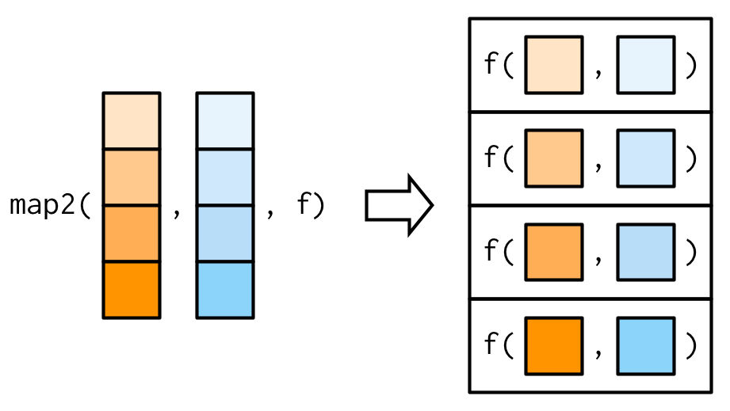

Illustration of how map2 works from Advanced R by Hadley Wickham

#### *pmap*

*pmap* works exactly like *map2* but for more that two arguments. The key difference is that the list of arguments need to be within *list()*. The figure below from [Advacned R](https://adv-r.hadley.nz/functionals.html#map-variants) illustrates how the *pmap* function works.

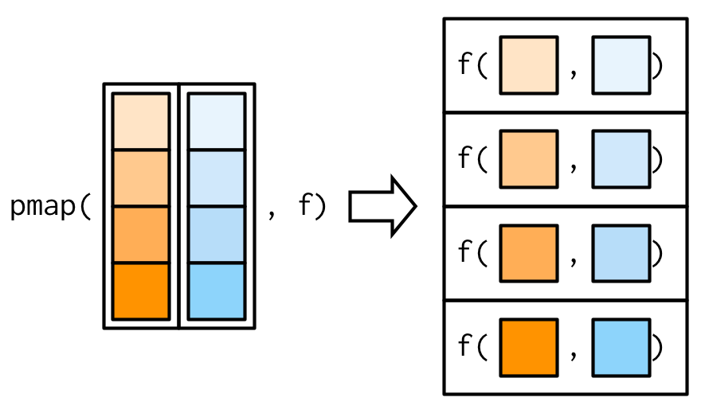

Illustration of how pmap works from Advanced R by Hadley Wickham

```r
n <- list(1, 2, 3)
min <- list(0, 10, 100)
max <- list(1, 100, 1000)

pmap(list(n, min, max), runif) # use list in pmap to list all the arguments
```

```
## [[1]]
## [1] 0.899112
##
## [[2]]
## [1] 99.07672 39.21282
##
## [[3]]
## [1] 456.7882 683.4203 691.2178
```

You might have noticed that across all these examples the length of each list used in *map2* and *pmap* were the same length. If they are different length you will get an error (see below).

```r
n <- list(1, 2, 3)
min <- list(0, 10, 100)
max <- list(1, 100, 1000, 10000)

pmap(list(n, min, max), runif) # all lists must be the same length
```

```
## Error: Element 1 of `.l` must have length 1 or 4, not 3
```

## The *walk* function

In addition to *map* and it’s varieties there is *walk*. The *walk* function works exactly like *map* including the *walk2* and *pwalk*. The difference is that *walk* is used when you want to call the side effects of a function (i.e. write_csv, ggsave). Typically, I will use this when a function manipulates a list and I want to save each element individually. For example this is great for saving vector layers of an sf object as their own spatial file.

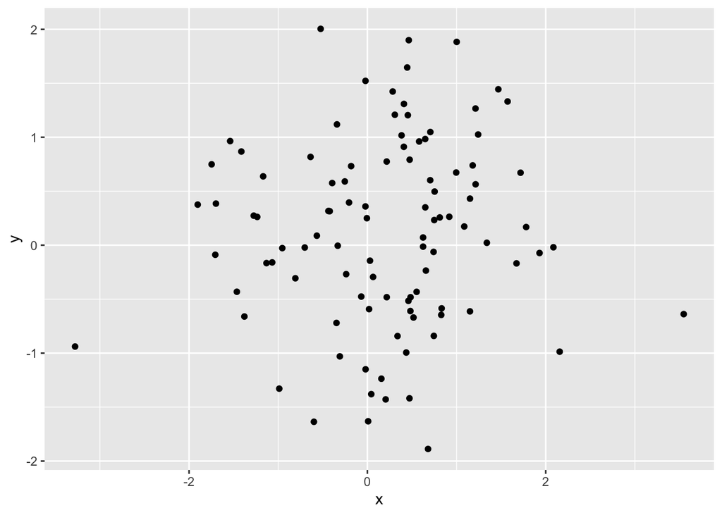

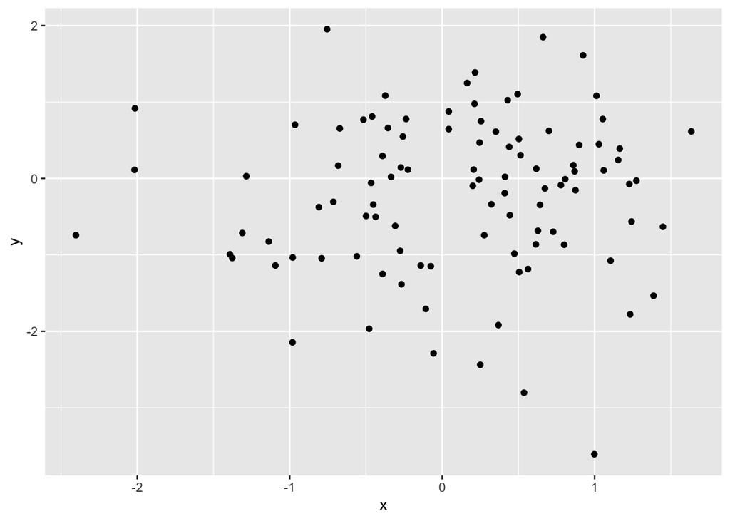

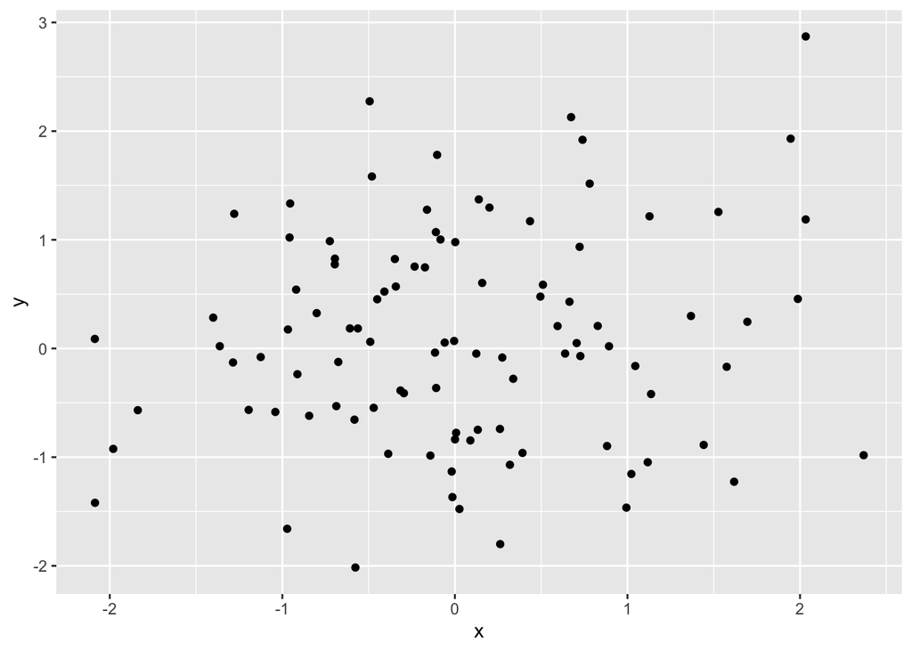

```r
rerun(3, x = rnorm(100), y = rnorm(100)) %>% # create 5 lists of random numbers
    map(~ data.frame(.x)) %>% # convert each list to a df
    walk(function(df) {
        p <- ggplot(df, aes(x = x, y = y)) + geom_point() # apply the walk function to produce plat
        p
    })

rerun(3, x = rnorm(100), y = rnorm(100)) %>% # create 5 lists of random numbers
    map(~ data.frame(.x)) %>% # convert each list to a df
    walk(function(df) {
        p <- ggplot(df, aes(x = x, y = y)) + geom_point() # apply the walk function to produce plat
        print(p) # walk function results in the plots stored in p being printed
    })
```

## Error proof your fucntions…kind of

As illustrated in a few examples above, when *map* encounters an error is stops running and gives you that error. This is good for knowing something went wrong but disappointing if the error was in element 60000 of a vector. You lose all the previously successful runs of *map* on the previous elements and have to fix the error and start over.

Thankfully, there is the *safely* function. *safely* is a wrapper for other functions that changes how the output is produced. For each element you are applying a function to with *map*, *safely* outputs a multi-level list where each element has */$results* and */$error*. Result stores the successful runs of your function and error stores any error messages. From this output you can see where your function did not run while keeping the successful runs. After fixing your function you can rerun it on only those that had an error and save substantial processing time. Below is an example of this.

```r
list.4 <- list(a = runif(10, 0, 100),
            b = rep("a", 10),
            c = runif(10, 0, 100),
            d = runif(10, 0, 100),
            e = runif(10, 0, 100)
            )

list.4 %>%
  map(log) # error due to "a" in list
```

```
## Error in .Primitive("log")(x, base): non-numeric argument to mathematical function
```

```r
list.4 %>%
  map(safely(log)) # wrap the log function in the safely function to store errors and results
```

```
## $a
## $a$result
##  [1] 4.459458 3.704060 4.257675 4.364407 4.143604 3.035189 4.525886 2.776304
##  [9] 2.331753 4.589831
##
## $a$error
## NULL
##
##
## $b
## $b$result
## NULL
##
## $b$error
## <simpleError in .Primitive("log")(x, base): non-numeric argument to mathematical function>
##
##
## $c
## $c$result
##  [1] 2.200414 3.812061 4.525591 4.517712 2.569528 4.466388 2.185883 4.428468
##  [9] 3.797367 4.376846
##
## $c$error
## NULL
##
##
## $d
## $d$result
##  [1] 3.670640 3.921742 4.404143 4.545850 3.273702 4.148259 3.123942 3.574256
##  [9] 4.203094 3.753013
##
## $d$error
## NULL
##
##
## $e
## $e$result
##  [1] 4.404175 3.535715 4.397310 4.416164 4.494827 3.865139 4.438790 3.501757
##  [9] 4.338972 3.808627
##
## $e$error
## NULL
```

```r
list.4_error <- list.4 %>%
  map(safely(log)) %>%
  map("error") # shortcut to extract element based on "name"
list.4_error
```

```
## $a
## NULL
##
## $b
## <simpleError in .Primitive("log")(x, base): non-numeric argument to mathematical function>
##
## $c
## NULL
##
## $d
## NULL
##
## $e
## NULL
```

```r
list.4_result <- list.4 %>%
  map(safely(log)) %>%
  map("result") %>% # shortcut to extract element based on "name"
  compact()
list.4_result
```

```
## $a
##  [1] 4.459458 3.704060 4.257675 4.364407 4.143604 3.035189 4.525886 2.776304
##  [9] 2.331753 4.589831
##
## $c
##  [1] 2.200414 3.812061 4.525591 4.517712 2.569528 4.466388 2.185883 4.428468
##  [9] 3.797367 4.376846
##
## $d
##  [1] 3.670640 3.921742 4.404143 4.545850 3.273702 4.148259 3.123942 3.574256
##  [9] 4.203094 3.753013
##
## $e
##  [1] 4.404175 3.535715 4.397310 4.416164 4.494827 3.865139 4.438790 3.501757
##  [9] 4.338972 3.808627
```

The vector with an “a” obviously produced an error when attempting to log. However, if you didn’t know there was an issue there you could easily fix it now and only rerun that vector.

# *tidyr*: Nested Dataframes

This section focuses on how to use *map* when working with dataframes. To do this we need to use the *tidyr* package. Specifically, the *nest* function which creates a list column in a dataframe. You can treat this list column exactly like you would a traditional list with a little help from dplyr.

**Note** the examples below were taken directly from the [Many Models](https://r4ds.had.co.nz/many-models.html) chapter of R for Data Science.

We will be using the **gapminder** data set of life expectancy, population, and GDP for countries across the world. Based on the figure below you can see that there is a general increase in life expectancy across the world with a few major dips. Using *tidyr*, *map*, and the *broom* package we will model this relationship all within a dataframe.

```r
gapminder
```

```
## # A tibble: 1,704 x 6
##    country     continent  year lifeExp      pop gdpPercap
##    <fct>       <fct>     <int>   <dbl>    <int>     <dbl>
##  1 Afghanistan Asia       1952    28.8  8425333      779.
##  2 Afghanistan Asia       1957    30.3  9240934      821.
##  3 Afghanistan Asia       1962    32.0 10267083      853.
##  4 Afghanistan Asia       1967    34.0 11537966      836.
##  5 Afghanistan Asia       1972    36.1 13079460      740.
##  6 Afghanistan Asia       1977    38.4 14880372      786.
##  7 Afghanistan Asia       1982    39.9 12881816      978.
##  8 Afghanistan Asia       1987    40.8 13867957      852.
##  9 Afghanistan Asia       1992    41.7 16317921      649.
## 10 Afghanistan Asia       1997    41.8 22227415      635.
## # … with 1,694 more rows
```

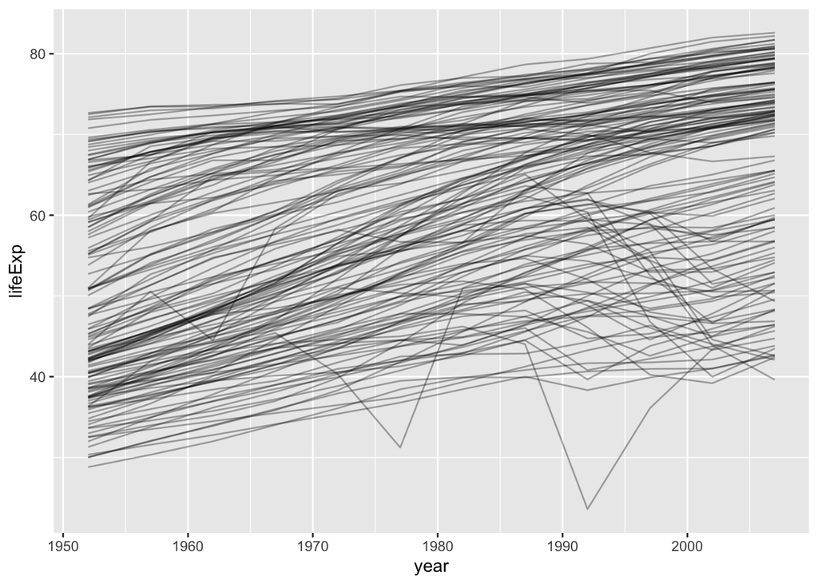

```r
gapminder %>%
  ggplot(aes(year, lifeExp, group = country)) +
    geom_line(alpha = 1/3)
```

We can use the **gapminder** dataset to investigate the pattern of life expectancy over time for a singular country.

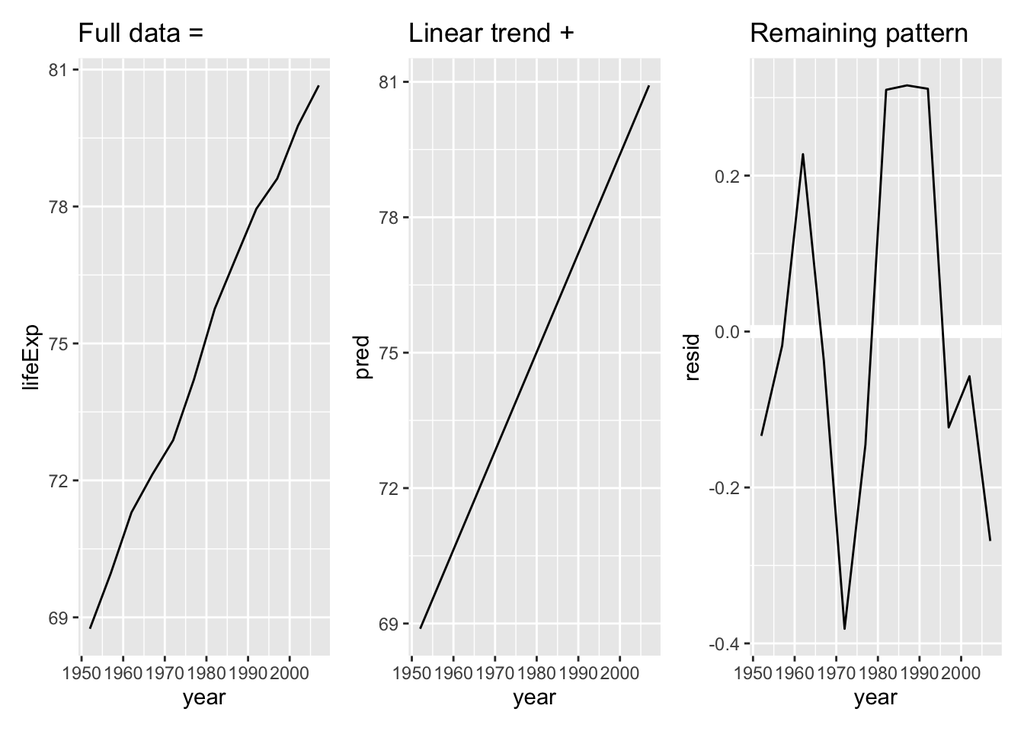

```r
ca <- filter(gapminder, country == "Canada")
full_plot <- ca %>%
  ggplot(aes(year, lifeExp)) +
  geom_line() +
  ggtitle("Full data = ")

ca_mod <- lm(lifeExp ~ year, data = ca)
lin_plot <- ca %>%
  modelr::add_predictions(ca_mod) %>%
  ggplot(aes(year, pred)) +
  geom_line() +
  ggtitle("Linear trend + ")

res_plot <- ca %>%
  modelr::add_residuals(ca_mod) %>%
  ggplot(aes(year, resid)) +
  geom_hline(yintercept = 0, colour = "white", size = 3) +
  geom_line() +
  ggtitle("Remaining pattern")


full_plot + lin_plot + res_plot
```

This is useful but impractical to run individually for all 142 countries in the dataset. This is when *nest* from *tidyr* comes in handy. As mentioned, *nest* creates a list-column in the dataframe according to the defined grouping factor. In other words, anything not in the grouping factor is stored in a single **data** column.

```r
by_country <- gapminder %>%
  group_by(country, continent) %>% # chose grouping factor
  nest() # nest according to the grouping

by_country
```

```
## # A tibble: 142 x 3
## # Groups:   country, continent [710]
##    country     continent data
##    <fct>       <fct>     <list>
##  1 Afghanistan Asia      <tibble [12 × 4]>
##  2 Albania     Europe    <tibble [12 × 4]>
##  3 Algeria     Africa    <tibble [12 × 4]>
##  4 Angola      Africa    <tibble [12 × 4]>
##  5 Argentina   Americas  <tibble [12 × 4]>
##  6 Australia   Oceania   <tibble [12 × 4]>
##  7 Austria     Europe    <tibble [12 × 4]>
##  8 Bahrain     Asia      <tibble [12 × 4]>
##  9 Bangladesh  Asia      <tibble [12 × 4]>
## 10 Belgium     Europe    <tibble [12 × 4]>
## # … with 132 more rows
```

```r
by_country$data[[1]] # select the first element in the column just like you would for a list
```

```
## # A tibble: 12 x 4
##     year lifeExp      pop gdpPercap
##    <int>   <dbl>    <int>     <dbl>
##  1  1952    28.8  8425333      779.
##  2  1957    30.3  9240934      821.
##  3  1962    32.0 10267083      853.
##  4  1967    34.0 11537966      836.
##  5  1972    36.1 13079460      740.
##  6  1977    38.4 14880372      786.
##  7  1982    39.9 12881816      978.
##  8  1987    40.8 13867957      852.
##  9  1992    41.7 16317921      649.
## 10  1997    41.8 22227415      635.
## 11  2002    42.1 25268405      727.
## 12  2007    43.8 31889923      975.
```

```r
by_country %>%
  unnest(data) # unnest the data to return to its original configuation.
```

```
## # A tibble: 1,704 x 6
## # Groups:   country, continent [710]
##    country     continent  year lifeExp      pop gdpPercap
##    <fct>       <fct>     <int>   <dbl>    <int>     <dbl>
##  1 Afghanistan Asia       1952    28.8  8425333      779.
##  2 Afghanistan Asia       1957    30.3  9240934      821.
##  3 Afghanistan Asia       1962    32.0 10267083      853.
##  4 Afghanistan Asia       1967    34.0 11537966      836.
##  5 Afghanistan Asia       1972    36.1 13079460      740.
##  6 Afghanistan Asia       1977    38.4 14880372      786.
##  7 Afghanistan Asia       1982    39.9 12881816      978.
##  8 Afghanistan Asia       1987    40.8 13867957      852.
##  9 Afghanistan Asia       1992    41.7 16317921      649.
## 10 Afghanistan Asia       1997    41.8 22227415      635.
## # … with 1,694 more rows
```

Now that you have nested the dataframe you can apply a model to each row. By creating a model function you can use it with *map* exactly like you did with any other function. Importantly, you need to remember that you are working in a dataframe so you need to use *dplyr::mutate* to create a new column with the model output.

```r
country_model <- function(df) {
  lm(lifeExp ~ year, data = df)
}

by_country_model <- by_country %>%
  mutate(model = map(data, country_model))

by_country_model
```

```
## # A tibble: 142 x 4
## # Groups:   country, continent [710]
##    country     continent data              model
##    <fct>       <fct>     <list>            <list>
##  1 Afghanistan Asia      <tibble [12 × 4]> <lm>
##  2 Albania     Europe    <tibble [12 × 4]> <lm>
##  3 Algeria     Africa    <tibble [12 × 4]> <lm>
##  4 Angola      Africa    <tibble [12 × 4]> <lm>
##  5 Argentina   Americas  <tibble [12 × 4]> <lm>
##  6 Australia   Oceania   <tibble [12 × 4]> <lm>
##  7 Austria     Europe    <tibble [12 × 4]> <lm>
##  8 Bahrain     Asia      <tibble [12 × 4]> <lm>
##  9 Bangladesh  Asia      <tibble [12 × 4]> <lm>
## 10 Belgium     Europe    <tibble [12 × 4]> <lm>
## # … with 132 more rows
```

```r
by_country_model$model[[1]] # select the first element to see the result
```

```
##
## Call:
## lm(formula = lifeExp ~ year, data = df)
##
## Coefficients:
## (Intercept)         year
##   -507.5343       0.2753
```

Since you are still working with a dataframe all the *tidyverse*/dataframe functions still work. The nested model output will be carried though.

```r
by_country_model %>%
  filter(continent == "Europe") # filter to only countries in Europe
```

```
## # A tibble: 30 x 4
## # Groups:   country, continent [710]
##    country                continent data              model
##    <fct>                  <fct>     <list>            <list>
##  1 Albania                Europe    <tibble [12 × 4]> <lm>
##  2 Austria                Europe    <tibble [12 × 4]> <lm>
##  3 Belgium                Europe    <tibble [12 × 4]> <lm>
##  4 Bosnia and Herzegovina Europe    <tibble [12 × 4]> <lm>
##  5 Bulgaria               Europe    <tibble [12 × 4]> <lm>
##  6 Croatia                Europe    <tibble [12 × 4]> <lm>
##  7 Czech Republic         Europe    <tibble [12 × 4]> <lm>
##  8 Denmark                Europe    <tibble [12 × 4]> <lm>
##  9 Finland                Europe    <tibble [12 × 4]> <lm>
## 10 France                 Europe    <tibble [12 × 4]> <lm>
## # … with 20 more rows
```

```r
by_country_model %>%
  arrange(country) # arrange alphabetically by country
```

```
## # A tibble: 142 x 4
## # Groups:   country, continent [710]
##    country     continent data              model
##    <fct>       <fct>     <list>            <list>
##  1 Afghanistan Asia      <tibble [12 × 4]> <lm>
##  2 Albania     Europe    <tibble [12 × 4]> <lm>
##  3 Algeria     Africa    <tibble [12 × 4]> <lm>
##  4 Angola      Africa    <tibble [12 × 4]> <lm>
##  5 Argentina   Americas  <tibble [12 × 4]> <lm>
##  6 Australia   Oceania   <tibble [12 × 4]> <lm>
##  7 Austria     Europe    <tibble [12 × 4]> <lm>
##  8 Bahrain     Asia      <tibble [12 × 4]> <lm>
##  9 Bangladesh  Asia      <tibble [12 × 4]> <lm>
## 10 Belgium     Europe    <tibble [12 × 4]> <lm>
## # … with 132 more rows
```

You can also use the *model* column for any function that requires a model output as an input. Here, *add_residual* from *modelr* is used to add the residuals to the dataframe.

```r
by_country_resid <- by_country_model %>%
  mutate(
    resids = map2(data, model, modelr::add_residuals) # add the residuals for each model
  )

resids_df <- by_country_resid %>%
  unnest(cols = resids) # unnest the residual column only
```

Once unnested the dataframe expands and fills in the rows as needed. Any column that is not specified in *unnest* will remain nested.

Again because you are working with a dataframe you can easily plot with ggplot. Below is a plot of the newly calculated residuals across years and the residuals grouped by continent

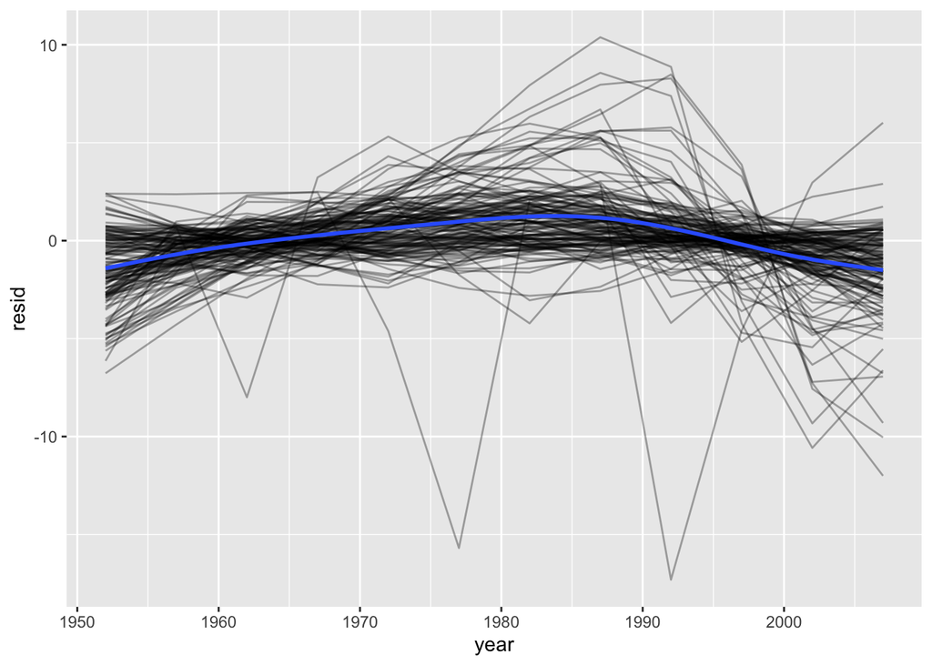

```r
resids_df %>%
  ggplot(aes(x = year, y = resid)) +
    geom_line(aes(group = country), alpha = 1 / 3) +
    geom_smooth(se = FALSE)
```

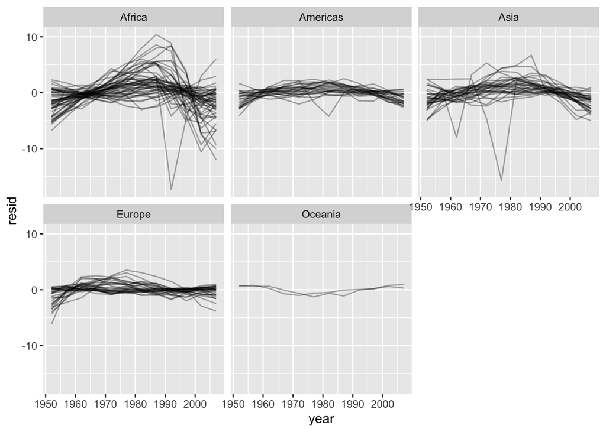

```r
resids_df %>%
  ggplot(aes(x = year, y = resid, group = country)) +
    geom_line(alpha = 1 / 3) +
    facet_wrap(~continent)
```

## Tidier models with *broom*

The above example of calculating residuals is a good introduction but would be limiting if you were interested in more information from the model. You may think that you could simply *unnest* the *model* column to access all the information stored there but unfortunately that produces an error

```r
by_country_model %>%
  unnest(model)
```

```
## Error: Input must be list of vectors
```

Thankfully this is why the *broom* package was created. *broom* converts model outputs to a tidy format so they can be used in dataframes. There are three functions that make up the core fucntion of *broom*.

- tidy: returns a row for each coefficient in the model. Each column gives information about the estimate or its variability.
- glance: returns a row for each model. Each column gives a model summary: either a measure of model quality, or complexity, or a combination of the two.
- augment: returns a row for each row in data, adding extra values like residuals, and influence statistics.

By using each of these you can extract all the necessary information from a model. Also, *broom* does not only work with *lm* it is also compatible with glm, nls, gam, mixed models, correlation, to name a few.

Below is an example of how to use tidy, glance, and augment from the *broom* package.

```r
by_country <- gapminder %>%
  group_by(country, continent) %>% #grouping factor
  nest()
```

```r
country_model_tidy <- function(df) {
  lm(lifeExp ~ year, data = df) # fit a lm
}

by_country_tidy_mod <- by_country %>%
  mutate(model = map(data, country_model), # apply lm to each nested df
         tidy_model = map(model, tidy),  # tidy the model output
         glance_model = map(model, glance), # apply glance to the model column
         augment_model = map(model, augment)) # apply augment to the model column

by_country_tidy_mod %>%
  unnest(tidy_model)
```

```
## # A tibble: 284 x 11
## # Groups:   country, continent [710]
##    country continent data  model term  estimate std.error statistic  p.value
##    <fct>   <fct>     <lis> <lis> <chr>    <dbl>     <dbl>     <dbl>    <dbl>
##  1 Afghan… Asia      <tib… <lm>  (Int… -5.08e+2  40.5        -12.5  1.93e- 7
##  2 Afghan… Asia      <tib… <lm>  year   2.75e-1   0.0205      13.5  9.84e- 8
##  3 Albania Europe    <tib… <lm>  (Int… -5.94e+2  65.7         -9.05 3.94e- 6
##  4 Albania Europe    <tib… <lm>  year   3.35e-1   0.0332      10.1  1.46e- 6
##  5 Algeria Africa    <tib… <lm>  (Int… -1.07e+3  43.8        -24.4  3.07e-10
##  6 Algeria Africa    <tib… <lm>  year   5.69e-1   0.0221      25.7  1.81e-10
##  7 Angola  Africa    <tib… <lm>  (Int… -3.77e+2  46.6         -8.08 1.08e- 5
##  8 Angola  Africa    <tib… <lm>  year   2.09e-1   0.0235       8.90 4.59e- 6
##  9 Argent… Americas  <tib… <lm>  (Int… -3.90e+2   9.68       -40.3  2.14e-12
## 10 Argent… Americas  <tib… <lm>  year   2.32e-1   0.00489     47.4  4.22e-13
## # … with 274 more rows, and 2 more variables: glance_model <list>,
## #   augment_model <list>
```

```r
by_country_tidy_mod %>%
  unnest(glance_model)
```

```
## # A tibble: 142 x 17
## # Groups:   country, continent [710]
##    country continent data  model tidy_model r.squared adj.r.squared sigma
##    <fct>   <fct>     <lis> <lis> <list>         <dbl>         <dbl> <dbl>
##  1 Afghan… Asia      <tib… <lm>  <tibble […     0.948         0.942 1.22
##  2 Albania Europe    <tib… <lm>  <tibble […     0.911         0.902 1.98
##  3 Algeria Africa    <tib… <lm>  <tibble […     0.985         0.984 1.32
##  4 Angola  Africa    <tib… <lm>  <tibble […     0.888         0.877 1.41
##  5 Argent… Americas  <tib… <lm>  <tibble […     0.996         0.995 0.292
##  6 Austra… Oceania   <tib… <lm>  <tibble […     0.980         0.978 0.621
##  7 Austria Europe    <tib… <lm>  <tibble […     0.992         0.991 0.407
##  8 Bahrain Asia      <tib… <lm>  <tibble […     0.967         0.963 1.64
##  9 Bangla… Asia      <tib… <lm>  <tibble […     0.989         0.988 0.977
## 10 Belgium Europe    <tib… <lm>  <tibble […     0.995         0.994 0.293
## # … with 132 more rows, and 9 more variables: statistic <dbl>, p.value <dbl>,
## #   df <int>, logLik <dbl>, AIC <dbl>, BIC <dbl>, deviance <dbl>,
## #   df.residual <int>, augment_model <list>
```

```r
by_country_tidy_mod %>%
  unnest(augment_model)
```

```
## # A tibble: 1,704 x 15
## # Groups:   country, continent [710]
##    country continent data  model tidy_model glance_model lifeExp  year .fitted
##    <fct>   <fct>     <lis> <lis> <list>     <list>         <dbl> <int>   <dbl>
##  1 Afghan… Asia      <tib… <lm>  <tibble [… <tibble [1 …    28.8  1952    29.9
##  2 Afghan… Asia      <tib… <lm>  <tibble [… <tibble [1 …    30.3  1957    31.3
##  3 Afghan… Asia      <tib… <lm>  <tibble [… <tibble [1 …    32.0  1962    32.7
##  4 Afghan… Asia      <tib… <lm>  <tibble [… <tibble [1 …    34.0  1967    34.0
##  5 Afghan… Asia      <tib… <lm>  <tibble [… <tibble [1 …    36.1  1972    35.4
##  6 Afghan… Asia      <tib… <lm>  <tibble [… <tibble [1 …    38.4  1977    36.8
##  7 Afghan… Asia      <tib… <lm>  <tibble [… <tibble [1 …    39.9  1982    38.2
##  8 Afghan… Asia      <tib… <lm>  <tibble [… <tibble [1 …    40.8  1987    39.5
##  9 Afghan… Asia      <tib… <lm>  <tibble [… <tibble [1 …    41.7  1992    40.9
## 10 Afghan… Asia      <tib… <lm>  <tibble [… <tibble [1 …    41.8  1997    42.3
## # … with 1,694 more rows, and 6 more variables: .se.fit <dbl>, .resid <dbl>,
## #   .hat <dbl>, .sigma <dbl>, .cooksd <dbl>, .std.resid <dbl>
```

```r
by_country_tidy_mod %>%
  unnest(tidy_model) %>%
  filter(term != "(Intercept)") %>% # remove the intercept from the dataframe
  filter(p.value <= 0.5) # select only significant values
```

```
## # A tibble: 140 x 11
## # Groups:   country, continent [710]
##    country continent data  model term  estimate std.error statistic  p.value
##    <fct>   <fct>     <lis> <lis> <chr>    <dbl>     <dbl>     <dbl>    <dbl>
##  1 Afghan… Asia      <tib… <lm>  year     0.275   0.0205      13.5  9.84e- 8
##  2 Albania Europe    <tib… <lm>  year     0.335   0.0332      10.1  1.46e- 6
##  3 Algeria Africa    <tib… <lm>  year     0.569   0.0221      25.7  1.81e-10
##  4 Angola  Africa    <tib… <lm>  year     0.209   0.0235       8.90 4.59e- 6
##  5 Argent… Americas  <tib… <lm>  year     0.232   0.00489     47.4  4.22e-13
##  6 Austra… Oceania   <tib… <lm>  year     0.228   0.0104      21.9  8.67e-10
##  7 Austria Europe    <tib… <lm>  year     0.242   0.00681     35.5  7.44e-12
##  8 Bahrain Asia      <tib… <lm>  year     0.468   0.0274      17.0  1.02e- 8
##  9 Bangla… Asia      <tib… <lm>  year     0.498   0.0163      30.5  3.37e-11
## 10 Belgium Europe    <tib… <lm>  year     0.209   0.00490     42.7  1.20e-12
## # … with 130 more rows, and 2 more variables: glance_model <list>,
## #   augment_model <list>
```

```r
by_country_tidy_mod %>%
  unnest(tidy_model) %>%
  filter(term != "(Intercept)") %>%
  filter(p.value <= 0.5) %>%
  unnest(augment_model, .drop = T) %>% #unnest the augment column and drop and duplicate columns
  filter(continent == "Europe") # filter to only Europe
```

```
## # A tibble: 360 x 19
## # Groups:   country, continent [710]
##    country continent data  model term  estimate std.error statistic p.value
##    <fct>   <fct>     <lis> <lis> <chr>    <dbl>     <dbl>     <dbl>   <dbl>
##  1 Albania Europe    <tib… <lm>  year     0.335    0.0332      10.1 1.46e-6
##  2 Albania Europe    <tib… <lm>  year     0.335    0.0332      10.1 1.46e-6
##  3 Albania Europe    <tib… <lm>  year     0.335    0.0332      10.1 1.46e-6
##  4 Albania Europe    <tib… <lm>  year     0.335    0.0332      10.1 1.46e-6
##  5 Albania Europe    <tib… <lm>  year     0.335    0.0332      10.1 1.46e-6
##  6 Albania Europe    <tib… <lm>  year     0.335    0.0332      10.1 1.46e-6
##  7 Albania Europe    <tib… <lm>  year     0.335    0.0332      10.1 1.46e-6
##  8 Albania Europe    <tib… <lm>  year     0.335    0.0332      10.1 1.46e-6
##  9 Albania Europe    <tib… <lm>  year     0.335    0.0332      10.1 1.46e-6
## 10 Albania Europe    <tib… <lm>  year     0.335    0.0332      10.1 1.46e-6
## # … with 350 more rows, and 10 more variables: glance_model <list>,
## #   lifeExp <dbl>, year <int>, .fitted <dbl>, .se.fit <dbl>, .resid <dbl>,
## #   .hat <dbl>, .sigma <dbl>, .cooksd <dbl>, .std.resid <dbl>
```

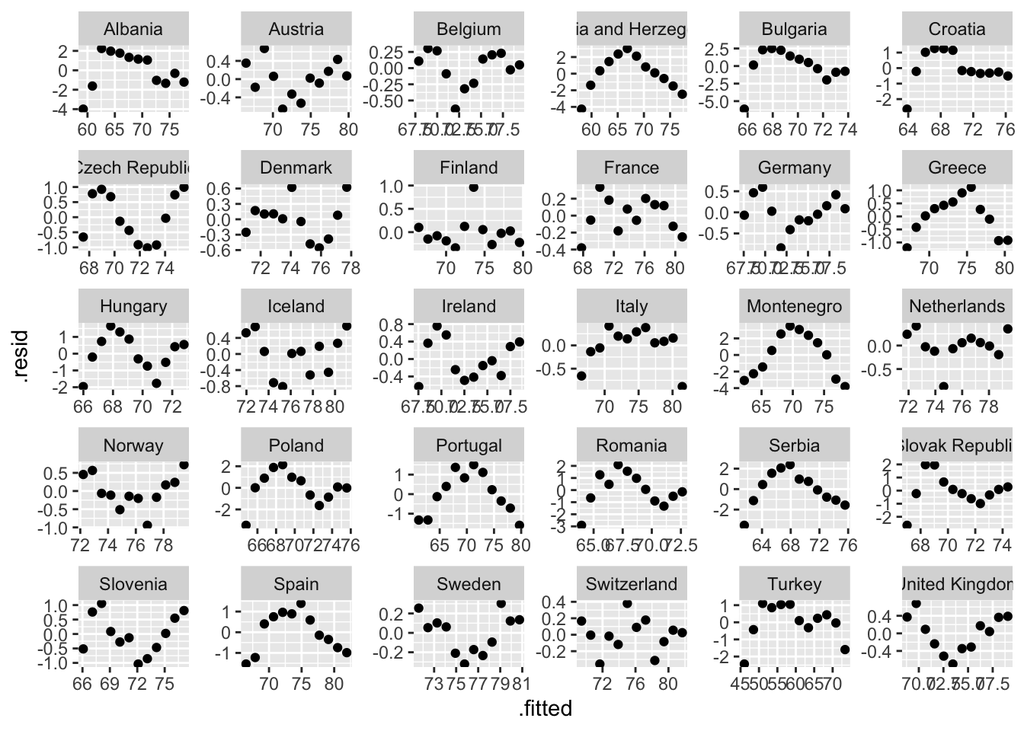

```r
by_country_tidy_mod %>%
  unnest(tidy_model) %>%
  filter(term != "(Intercept)") %>%
  filter(p.value <= 0.5) %>%
  unnest(augment_model, .drop = T) %>%
  filter(continent == "Europe")%>%
  ggplot(aes(x = .fitted, y = .resid, fill = country)) +
  geom_point() +
  facet_wrap(~country, scales = "free") +
  theme(legend.position = "none")
```